# Adding chain lightning

A fun addition to our lightning effect is having it bounce between objects.

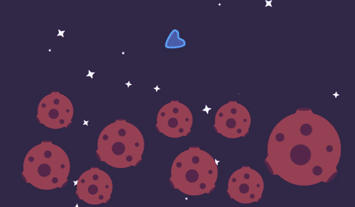

## Updating the Lighting Beam scene

The first thing we need to do is define a jump range. Open the *LightingBeam* scene and add an *Area2D* as a child. As a child of that, add a *CollisionShape2D*.

[figure not shown]

Over in the inspector, we add a new *CircleShape2D* and set the radius. I used `128`.

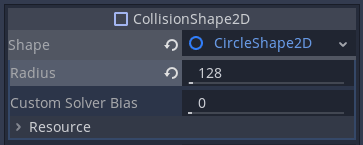

This means if there’s a body within 128 pixels of the end point, we can jump to it.

## Updating the Lightning Beam script

In `LightningBeam.gd`, we define the maximum times the lightning can bounce and cache *JumpArea*.

```
#...
export (int, 0, 10) var bounces_max := 3

#...
onready var jump_area := $JumpArea
```

We make sure the jump area’s position is always the same as the target point, as that’s where we’re jumping from.

```
func _physics_process(delta):
    #...

    jump_area.global_position = target_point
```

The `shoot()` function receives the most changes. We store all static bodies from `jump_area` in `_secondary_bodies`, but remove `_primary_body` because we don’t want the lightning to jump to the first target. In this case, it wouldn’t jump at all!

If the ray cast has a collision, we update the target point to its position.

```
func shoot() -> void:
    var _target_point = target_point

    var _primary_body = get_collider()
    var _secondary_bodies = jump_area.get_overlapping_bodies()

    if _primary_body:
        _secondary_bodies.erase(_primary_body)
        _target_point = _primary_body.global_position
    #...
```

We’re going to handle jumping jolts a little differently. Rather than having them start at the end of the last jolt, we’ll have them originate from the previous body’s position. I chose to do it this way as it looks like the body is taking in the lightning before expelling it to the next target.

First, we introduce the `_start` variable, which will change as we instance jolts.

```
func shoot() -> void:
    #...

    for flash in range(flashes):
        var _start = global_position

        var jolt = lightning_jolt.instance()
        add_child(jolt)
        jolt.create(_start, target_point)
```

Under this code, we have the following loop.

This loop works much like how our lighting jolt is shaped: we grab a body from secondary bodies and instance a jolt to its position before updating the start point again and moving on.

```
func shoot() -> void:
    #...
    for flash in range(flashes):
        #...

        # reset the starting point
        _start = _target_point
        # loops for bounces_max, or number of bodies; whichever is smaller
        for _i in range(min(bounces_max, _secondary_bodies.size())):
            var _body = _secondary_bodies[_i]

            jolt = lightning_jolt.instance()
            add_child(jolt)
            jolt.create(_start, _body.global_position)

            _start = _body.global_position

        yield(get_tree().create_timer(flash_time), "timeout")
```

We have a slight issue, however. If you run a scene with multiple static bodies, you may notice the sparks are sent to the center of the secondary bodies. We want our sparks to appear at the point of collision. To solve this, we’ll add a *RayCast2D* to our *LightningJolt* scene so it can work out the collision point itself.

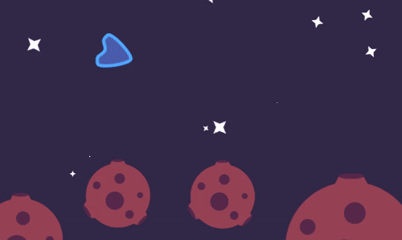

## Updating the Lighting Jolt scene

Add a *RayCast2D* to the *LightningJolt* scene.

[figure not shown]

## Updating Lightning Jolt script

We cache our *RayCast2D*.

```
extends Line2D

#...
onready var ray_cast := $RayCast2D
```

Then, we update the ray cast in the `create()` function.

```
func create(start: Vector2, end: Vector2) -> void:

    ray_cast.global_position = start

    ray_cast.cast_to = end - start
    ray_cast.force_raycast_update()

    if ray_cast.is_colliding():
        end = ray_cast.get_collision_point()
    #...
```

And there we have it: lightning that bounces between static bodies!

## Final updated LightningBeam.gd script

```
extends RayCast2D

export (int, 1, 10) var flashes := 3
export (float, 0.0, 3.0) var flash_time := 0.1
export (int, 0, 10) var bounces_max := 3
export var lightning_jolt: PackedScene = preload("res://LightningBeam/LightningJolt.tscn")

var target_point := Vector2.ZERO

onready var jump_area := $JumpArea


func _physics_process(delta) -> void:
    target_point = to_global(cast_to)

    if is_colliding():
        target_point = get_collision_point()

    jump_area.global_position = target_point


func shoot() -> void:
    var _target_point = target_point

    var _primary_body = get_collider()
    var _secondary_bodies = jump_area.get_overlapping_bodies()

    if _primary_body:
        _secondary_bodies.erase(_primary_body)
        _target_point = _primary_body.global_position

    for flash in range(flashes):
        var _start = global_position

        var jolt = lightning_jolt.instance()
        add_child(jolt)
        jolt.create(_start, target_point)

        _start = _target_point
        for _i in range(min(bounces_max, _secondary_bodies.size())):
            var _body = _secondary_bodies[_i]

            jolt = lightning_jolt.instance()
            add_child(jolt)
            jolt.create(_start, _body.global_position)

            _start = _body.global_position

        yield(get_tree().create_timer(flash_time), "timeout")
```

## Final updated LightningJolt.gd script

```
extends Line2D

export (float, 0.5, 3.0) var spread_angle := PI/4.0
export (int, 1, 36) var segments := 12

onready var sparks := $Sparks
onready var ray_cast := $RayCast2D


func _ready() -> void:
    set_as_toplevel(true)


func create(start: Vector2, end: Vector2) -> void:

    ray_cast.global_position = start

    ray_cast.cast_to = end - start
    ray_cast.force_raycast_update()

    if ray_cast.is_colliding():
        end = ray_cast.get_collision_point()

    var _points := []
    var _current := start
    var _segment_length := start.distance_to(end) / segments

    _points.append(start)

    for segment in range(segments):
        var _rotation := rand_range(-spread_angle / 2, spread_angle / 2)
        var _new := _current + (_current.direction_to(end) * _segment_length).rotated(_rotation)
        _points.append(_new)
        _current = _new

    _points.append(end)
    points = _points

    sparks.global_position = end
```